# RAMP-Uganda

David L Smith, Austin Carter

2023-08-21

Library $\uparrow$ Hub || Adaptive Malaria Control

- Adaptive malaria control is about giving countries the information they need

## Big Picture

- **Goals** – The goals of *malaria control* are to minimize the *health burden* of malaria and, ultimately, to *eliminate malaria* in Uganda, in alignment with a global, long-term goal to *eradicate malaria*
- **Policy** – Effective policy making requires a thorough understanding of the current malaria situation and the tradeoffs between interventions. Tradeoffs arise because of a *budget constraint* and uncertainty about the true effects of each intervention in different contexts. We want to *stratify* Uganda and *optimize* resource allocation to save lives and quickly eliminate malaria.
- **Advocacy** – For purposes of advocacy, we would also like to estimate the *burden* of malaria, the *averted burden*, and the cost and timeline of malaria elimination. Further, we want to be able to predict how these measures would change if the budget were increased.

## Details

- **Analytics**: Navigating tradeoffs requires a working knowledge of malaria epidemiology, malaria transmission, health systems, human behaviors, vector control, and costs. With so many moving parts, we need sophisticated analytic tools to construct an interpretable synthesis.
- **Uncertainty**: With imperfect information and a constantly changing body of evidence, we will also need robust algorithms for dealing with uncertainty.
- **Information Systems**: We need streamlined information systems to reduce the human workloads required to generate timely insights during repeated reporting on key malaria metrics.
- **Collaboration**: We are proposing a collaboration between the Uganda Ministry of Health, the University of Washington, and an analytics team in Uganda.
- **Adaptive Malaria Control**: Working together, we will develop protocols to review malaria policy, update surveillance systems, and adapt to changing conditions.

## Analytics

### Past, Present & Future

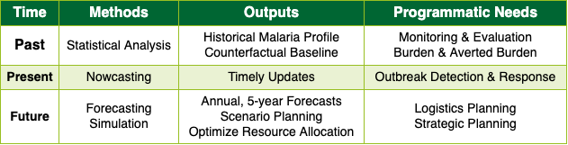

### Science vs. Policy

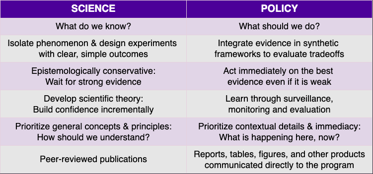

Science and policy have different goals

## Synthesis

- Malaria is a **disease** of **humans** caused by a **parasite** that is **transmitted** by **mosquitoes.**
- We understand the burden of malaria through **malaria epidemiology**:
  - A key risk factor for malaria is **exposure** to the bites of infective mosquitoes and **infection.**
  - The intensity of **exposure** varies because of **mosquito ecology** and other factors, including *weather* and *economic development.* The rate of **exposure** to the bites of infective mosquitoes can be reduced through **vector control.**
  - Outcomes of exposure and infection are modified by **malaria immunity**, which is related to a person’s age and their previous history of previous exposure. Malaria can be treated and cured with **anti-malarial drugs.** These drugs can also reduce transmission. Malaria outcomes are also inextricably linked to nutrition and other diseases.
  - Finally, as the risk of malaria declines in some urban areas, malaria is best understood and managed as a **travel disease.**
- We understand contemporary malaria epidemiology and transmission as a **baseline** – set by local environmental factors, such as rainfall and hydrololgy – that has been **modified by control**. The current **burden of malaria** does not include the **averted burden.**
  - The **shifting baseline** – due to *exogenous* factors such as rainfall, economic stress, or improved housing – can mask failures or successes of vector control.
  - The relationship between exposure and disease can be modified by **parasite** factors that can evolve over time.
  - The effects and effect sizes of vector control can be affected by **operational variance.** For example, the choice of an insecticide can lead to resurgence or improved control, depending on the relative effectiveness of these interventions in context. We’re also concerned about stock-outs, disruptions to the system (COVID).
  - The effects and effect sizes of health-based interventions and vector control can be modified by the **evolution of resistance.**
  - The accuracy of the surveillance. monitoring.
- Making malaria policy to minimize burden involves tradeoffs. We would like to use all the evidence at our disposal to understand those tradeoffs and adjust policies based on evidence of their effectiveness, or lack thereof. A challenge is that there are currently no perfect interventions. Over the short term they will reduce disease incrementally, and it is not clear what combination of interventions will lead to the greatest reductions in the burden of disease.
  - Expenditures on the health system, including medicines, that improve **case management** through increased care seeking and adherence to drug regimens. We understand care seeking as a complex behavioral phenomenon that can be modified through education, shifting social norms, and other factors. How do we change social behaviors. The end goal here is prompt treatment and cure for all malaria infections.
  - Expenditures on enhanced case management, including programs to provide chemoprotection to critical groups, such as intermittent presumptive therapy for pregnant women and infants. ICCM, PROCCM. Seasonal prophylaxis.
  - Expenditures on various modes of vector control, with the goal of reducing **transmission,** thereby reducing **exposure** and **disease**. Importantly, the effects and effect sizes of vector control depend on the behaviors of different vector species, and the mix of vectors in an area. The long-term goal is to interrupt transmission and eliminate it from Uganda.
  - Expenditures on malaria vaccines and other novel therapeutics, including monoclonal antibodies
  - General expenditures on health. We expect malaria control to reduce the risks of severe outcomes from other diseases, but we also expect the burden of malaria to be reduced by other interventions.
  - Investments in surveillance give us information about malaria on which to base our decisions.
- The tradeoffs are imposed by a **budget constraint,** but for **advocacy** we would also like to estimate the cost of malaria elimination. We want to do analysis to *optimize* interventions under that budget constraint.

## Robustness

- Uncertainty
- Science vs. policy
- Past and the Future
- Value of Information
- Adaptive Management

## Protocols

We need to set up protocals and procedures to use data, and to repeat our analysis after updating the data.

How we’re going to organize:

- Data & Curation
  - HMIS / DHIS2
  - UMSP
  - MAP / MIS / DHS
  - Intervention coverage (PMI-Vectorlink)
- Analytics Team
- Define Common Metrics / Terms
- Teams
  - Jimmy’s (MoH)
  - Rek / Pilgrim
  - Dave / UW
  - MAP …
- Annual Meeting / Big Tent
  - WHO / PMI / Malaria Consortium / PSI
  - Research
  - Academic partners

## Domains

- Policy
  - Budgets
  - Definitions
  - Scenarios
  - Priorities
  - Advocacy
  - Final Say
- Health Systems & Malaria
  - Facilities
  - Procurement (Diagnostics / Drugs)
  - Case Management / Drug Taking
  - Evolution of Resistance / Formulary
- Burden : Nutrition / Disease
  - Burden / Averted Burden estimation
  - Disease modulation
- Entomology
  - Insecticides
  - Insecticide Resistance
  - Mosquito Ecology
- Transmission & Epidemiology
  - Estimation / Transmission Intensity
  - Models
  - Propagating Uncertainty
- Demography
  - Denominators